# Lesson 6 : Diamonds And Price predictions

```r
library(ggplot2)
suppressMessages(library(dplyr))
library(tidyr)
suppressMessages(library(gridExtra))
suppressMessages(library(GGally))
library(RColorBrewer)
```

[Solomon’s blog: Analysis oof diamonds datsset](https://solomonmessing.wordpress.com/2014/01/19/visualization-series-the-scatterplot-or-how-to-use-data-so-you-dont-get-ripped-off/)

[Github link](https://github.com/SolomonMg/diamonds-data)

```r
# load data
data('diamonds')
summary(diamonds)
```

```
##      carat               cut        color        clarity
##  Min.   :0.2000   Fair     : 1610   D: 6775   SI1    :13065
##  1st Qu.:0.4000   Good     : 4906   E: 9797   VS2    :12258
##  Median :0.7000   Very Good:12082   F: 9542   SI2    : 9194
##  Mean   :0.7979   Premium  :13791   G:11292   VS1    : 8171
##  3rd Qu.:1.0400   Ideal    :21551   H: 8304   VVS2   : 5066
##  Max.   :5.0100                     I: 5422   VVS1   : 3655
##                                     J: 2808   (Other): 2531
##      depth           table           price             x
##  Min.   :43.00   Min.   :43.00   Min.   :  326   Min.   : 0.000
##  1st Qu.:61.00   1st Qu.:56.00   1st Qu.:  950   1st Qu.: 4.710
##  Median :61.80   Median :57.00   Median : 2401   Median : 5.700
##  Mean   :61.75   Mean   :57.46   Mean   : 3933   Mean   : 5.731
##  3rd Qu.:62.50   3rd Qu.:59.00   3rd Qu.: 5324   3rd Qu.: 6.540
##  Max.   :79.00   Max.   :95.00   Max.   :18823   Max.   :10.740
##
##        y                z
##  Min.   : 0.000   Min.   : 0.000
##  1st Qu.: 4.720   1st Qu.: 2.910
##  Median : 5.710   Median : 3.530
##  Mean   : 5.735   Mean   : 3.539
##  3rd Qu.: 6.540   3rd Qu.: 4.040
##  Max.   :58.900   Max.   :31.800
##
```

```r
str(diamonds)
```

```
## Classes 'tbl_df', 'tbl' and 'data.frame':    53940 obs. of  10 variables:
##  $ carat  : num  0.23 0.21 0.23 0.29 0.31 0.24 0.24 0.26 0.22 0.23 ...
##  $ cut    : Ord.factor w/ 5 levels "Fair"<"Good"<..: 5 4 2 4 2 3 3 3 1 3 ...
##  $ color  : Ord.factor w/ 7 levels "D"<"E"<"F"<"G"<..: 2 2 2 6 7 7 6 5 2 5 ...
##  $ clarity: Ord.factor w/ 8 levels "I1"<"SI2"<"SI1"<..: 2 3 5 4 2 6 7 3 4 5 ...
##  $ depth  : num  61.5 59.8 56.9 62.4 63.3 62.8 62.3 61.9 65.1 59.4 ...
##  $ table  : num  55 61 65 58 58 57 57 55 61 61 ...
##  $ price  : int  326 326 327 334 335 336 336 337 337 338 ...
##  $ x      : num  3.95 3.89 4.05 4.2 4.34 3.94 3.95 4.07 3.87 4 ...
##  $ y      : num  3.98 3.84 4.07 4.23 4.35 3.96 3.98 4.11 3.78 4.05 ...
##  $ z      : num  2.43 2.31 2.31 2.63 2.75 2.48 2.47 2.53 2.49 2.39 ...
```

### Scatterplot Review

Create a scatterplot of price (y) vs carat (x). Limit the x-axis and y-axis to omit the top 1% of values.

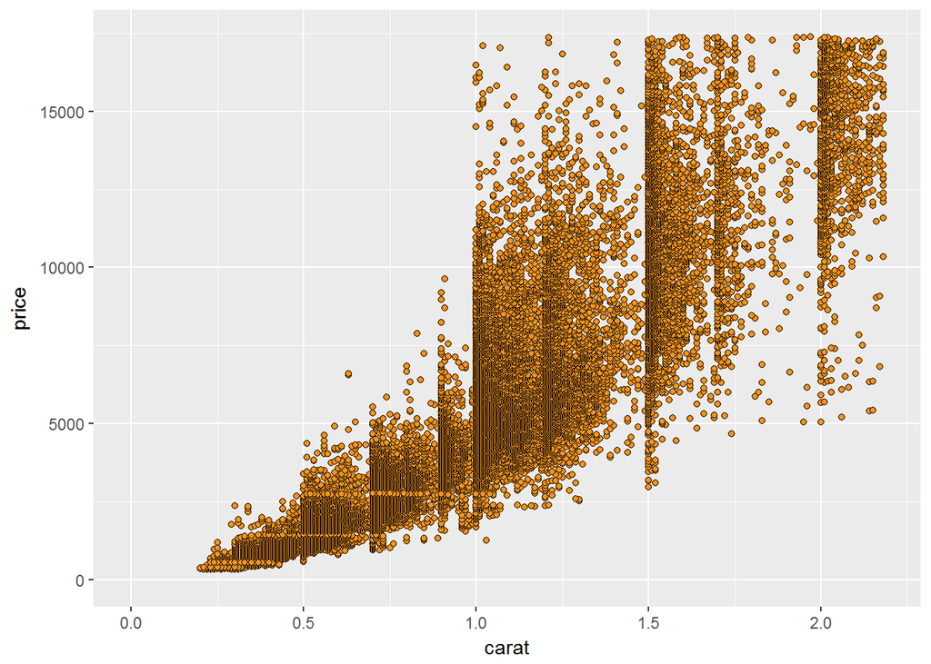

```r
ggplot(data = diamonds, aes(x = carat, y = price))+
  geom_point(shape = 21, color = 'black', fill = '#F79420')+
  scale_x_continuous(lim = c(0,quantile(diamonds$carat,0.99)))+
  scale_y_continuous(lim = c(0,quantile(diamonds$price,0.99)))
```

### Price and Carat Relationship

Response: On seeing the graph above we can make out that it is a non-linear relationship may be exponential or something else. We can also see that dispersion or variance of the relationship increases as carat size increases.

### ggpairs Function

Notes:

```r
# install these if necessary
#install.packages('GGally')
#install.packages('scales')
#install.packages('memisc')
#install.packages('lattice')
#install.packages('MASS')
#install.packages('car')
#install.packages('reshape2')

# load the ggplot graphics package and the others
suppressMessages(library(scales))
suppressMessages(library(memisc))
suppressMessages(library(car))
suppressMessages(library(MASS))
```

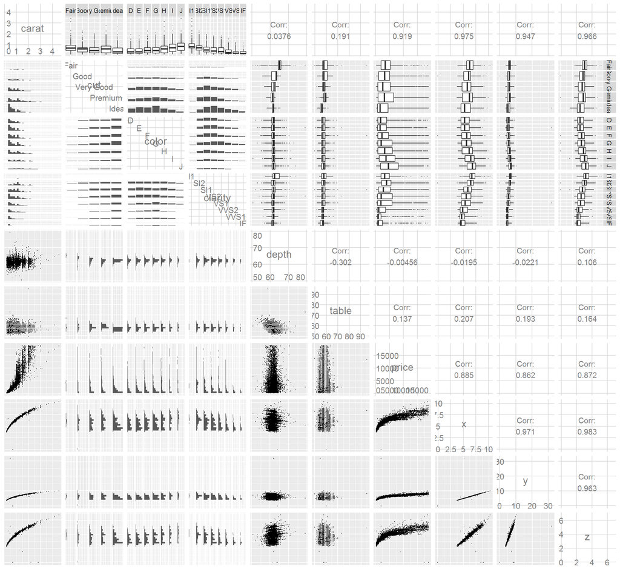

```r
# sample 10,000 diamonds from the data set
set.seed(20022012)
diamond_samp <- diamonds[sample(1:length(diamonds$price),10000), ]
ggpairs(diamond_samp,  axisLabels = 'internal',
        lower = list(continuous = wrap("points", shape = I('.'))),
        upper = list(combo = wrap("box", outlier.shape = I('.'))))
```

In the lower triangle of the plot matrix, it **uses grouped histograms for qualitative, qualitative pairs** and **scatter plots for quantitative, quantitative pairs**.

In the upper triangle, it **plots grouped histograms for qualitative, qualitative pairs, this time using the x instead of the y variable as the grouping factor**.

**Box plots for qualitative, quantitative pairs**, and it **provides the correlation for quantitative-quantitative pairs**.

#### Remember that our goal is to understand the price of diamonds. So, let’s focus on that.

What are some things you notice in the ggpairs output?

Response: We can see what might be relationships between price and clarity and price and color, which we’ll keep in mind for later when start modelling our data. You might remember this when you create the box plots in problem set three.

Be that as it may, **the critical factor driving price is the size, or the carat weight of the diamond**. As we saw at the start of the lesson, the relationship between price and diamond size is nonlinear. What might explain this pattern?

On the supply side, larger continuous chunks of diamonds without significant flaws are probably harder to find than smaller ones. This might help explain the sort of exponential looking curve,

### The Demand of Diamonds

Notes:

On the demand side, customers in the market for a less expensive, smaller diamond are probably more sensitive to price than more well-to-do buyers. Many less than one carat customers would surely never buy a diamond.

And there are fewer customers who can afford a bigger diamond that is one that is larger than than one carat, hence we shouldn’t expect the market for bigger diamonds to be as competitive as the one for smaller diamonds. So it makes sense that the variants As well as the price would increase with carat size.

##### Create two histograms of the price variable and place them side by side on one output image.

The first plot should be a histogram of price and the second plot should transform the price variable using log10.

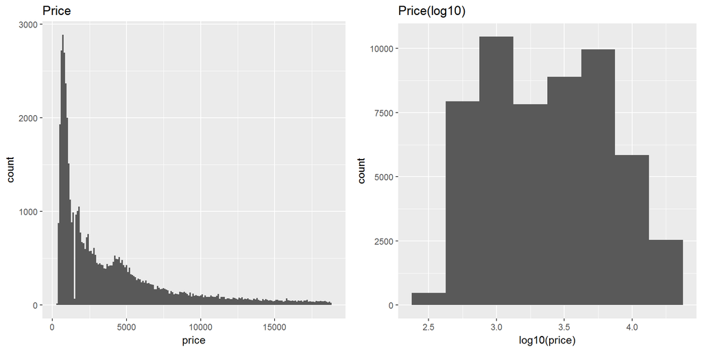

```r
plot1 <- ggplot(diamonds, aes(x = price)) +
  geom_histogram(binwidth=100) +
  labs(title='Price')

# Here i am converting prices to log
plot2 <- ggplot(diamonds, aes(x = log10(price))) +
  geom_histogram(binwidth = 0.25) +
  labs(title='Price(log10)')

grid.arrange(plot1, plot2, ncol=2)
```

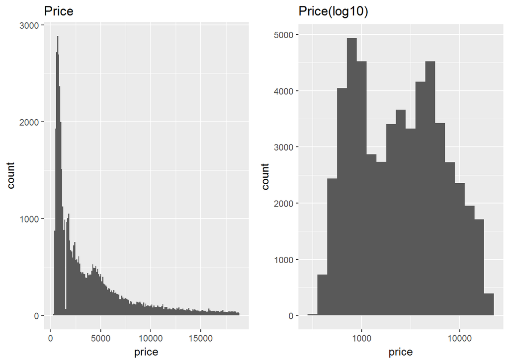

```r
plot1 <- ggplot(diamonds, aes(x = price)) +
  geom_histogram(binwidth = 100) +
  labs(title='Price')

# Here i am converting prices to log
plot2 <- ggplot(diamonds, aes(x = price)) +
  geom_histogram(binwidth = 0.1) +
  scale_x_log10()+
  labs(title='Price(log10)')

grid.arrange(plot1, plot2, ncol=2)
```

### Connecting Demand and Price Distributions

Notes:

Indeed we can see that the prices for diamonds are pretty heavily skewed, but when you put those prices on a log ten scale, they seem much better behaved. They’re **much closer to the bell curve of a normal distribution**. We can even see a **little bit of evidence of bimodality on this log10 scale. Which is consistent with our two class rich buyer-poor buyer speculation about the nature of customers for diamonds**. You actually saw a sneak peek of this in problem set set three when you looked at the log10 of price by cut. (Took facet_wrap)

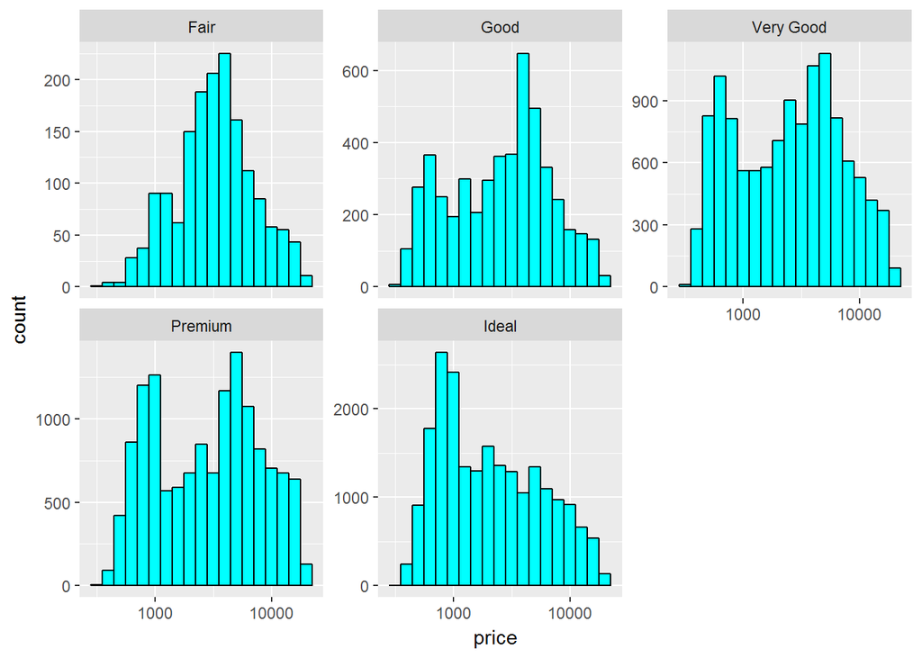

```r
ggplot(data = diamonds, aes(x = price))+
  geom_histogram(binwidth = 0.1,color = 'black', fill = '#00FFFF')+
  scale_x_log10() +
  facet_wrap( ~ cut, scales = "free_y")
```

### Scatterplot Transformation

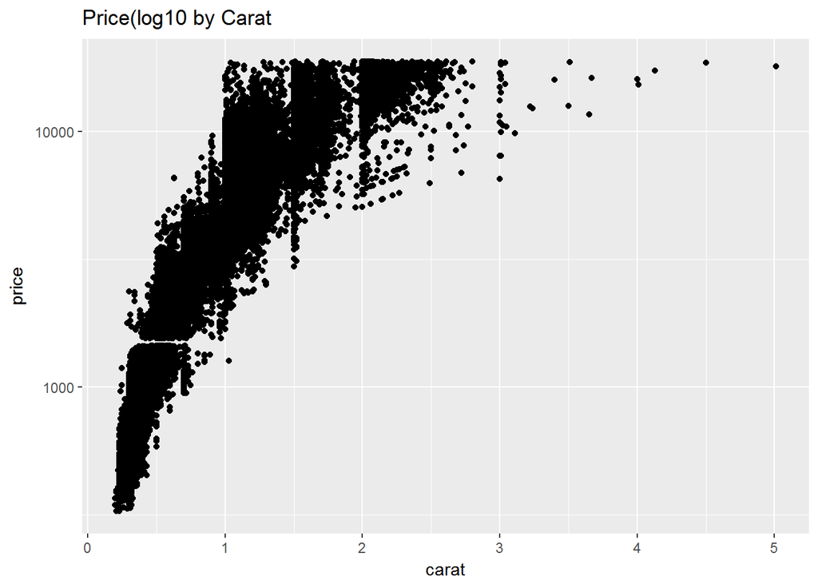

```r
ggplot(diamonds, aes(x=carat, y=price))+
  geom_point()+
  scale_y_continuous(trans = log10_trans())+
  labs(title='Price(log10 by Carat')
```

### Create a new function to transform the carat variable

```r
cuberoot_trans = function(x)
  { trans_new('cuberoot', transform = function(x) x^(1/3),
                                      inverse = function(x) x^3)
  }
```

#### Use the cuberoot_trans function

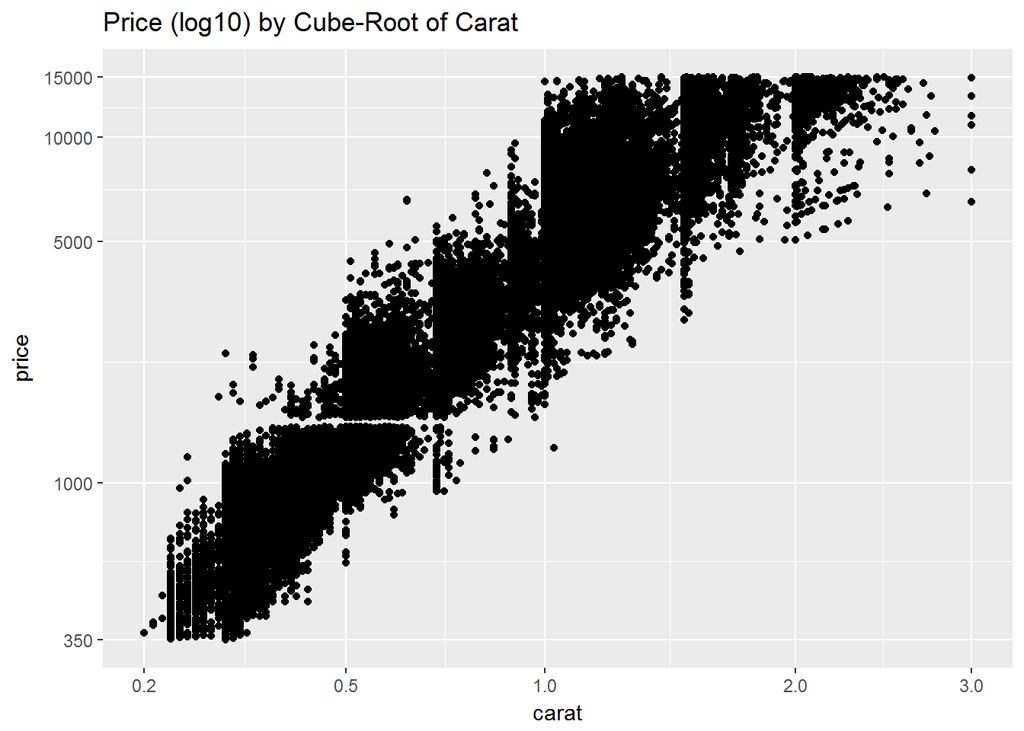

```r
ggplot(aes(carat, price), data = diamonds) +
  geom_point() +
  scale_x_continuous(trans = cuberoot_trans(), limits = c(0.2, 3),
                     breaks = c(0.2, 0.5, 1, 2, 3)) +
  scale_y_continuous(trans = log10_trans(), limits = c(350, 15000),
                     breaks = c(350, 1000, 5000, 10000, 15000)) +
  ggtitle('Price (log10) by Cube-Root of Carat')
```

### Overplotting Revisited

**Overplotting ;** That’s when multiple points take on the same value. This is often due to rounding.

```r
head(sort(table(diamonds$price), decreasing = T))
```

```
##
## 605 802 625 828 776 698
## 132 127 126 125 124 121
```

```r
head(sort(table(diamonds$carat), decreasing = T))
```

```
##
##  0.3 0.31 1.01  0.7 0.32    1
## 2604 2249 2242 1981 1840 1558
```

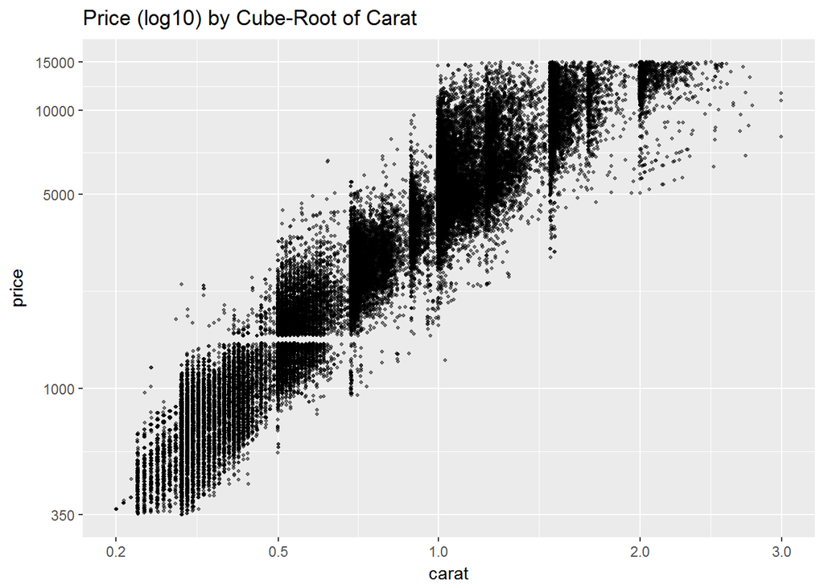

```r
ggplot(aes(carat, price), data = diamonds) +
  geom_point(alpha = 0.5, position = 'jitter', size = 3/4) +
  scale_x_continuous(trans = cuberoot_trans(), limits = c(0.2, 3),
                     breaks = c(0.2, 0.5, 1, 2, 3)) +
  scale_y_continuous(trans = log10_trans(), limits = c(350, 15000),
                     breaks = c(350, 1000, 5000, 10000, 15000)) +
  ggtitle('Price (log10) by Cube-Root of Carat')
```

The plot gives us a better sense of how dense and how sparse our data is at key places.

### Other Qualitative Factors

Notes:

We can see what looks like a almost linear relationship between carat weight and price after doing some transformations, but surely there are other factors that influence the price of a diamond. When I was looking around at diamonds I noticed that clarity seemed to factor into price.

Of course, many consumers are looking for a diamond of a certain minimum size. So we shouldn’t expect clarity to be as strong a factor as carat weight.

### Price vs. Carat and Clarity

Let’s see if clarity, cut, or color can explain some of the variants in price when we visualize it on our plot using color.

RColorBrewer provides three types of palettes: sequential, diverging and qualitative.

- **Sequential palettes** are suited to ordered data that progress from low to high.
- **Diverging palettes** are suited to centered data with extremes in either direction.
- **Qualitative palettes** are suited to nominal or categorical data.

We’ll start by examining clarity. This code visualizes price by carat. Adjust it to color the points by clarity

[Blog on color palette](http://data.library.virginia.edu/setting-up-color-palettes-in-r/) [Type:sequential,diverging and qualitative](https://www.e-education.psu.edu/geog486/node/1867) [Another imp blog](http://www.personal.psu.edu/cab38/ColorSch/ASApaper.html)

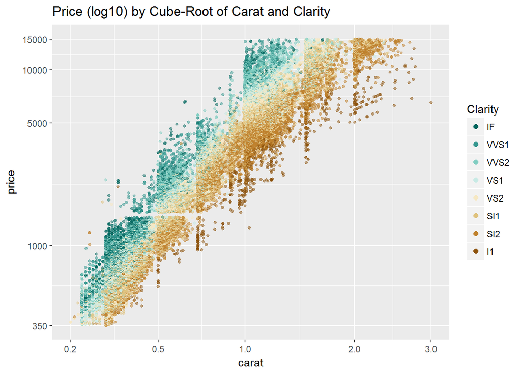

```r
ggplot(aes(x = carat, y = price,color = clarity), data = diamonds) +
  geom_point(alpha = 0.5, size = 1, position = 'jitter') +
  scale_color_brewer(type = 'div',
    guide = guide_legend(title = 'Clarity', reverse = T,
    override.aes = list(alpha = 1, size = 2))) +
  scale_x_continuous(trans = cuberoot_trans(), limits = c(0.2, 3),
    breaks = c(0.2, 0.5, 1, 2, 3)) +
  scale_y_continuous(trans = log10_trans(), limits = c(350, 15000),
    breaks = c(350, 1000, 5000, 10000, 15000)) +
  ggtitle('Price (log10) by Cube-Root of Carat and Clarity')
```

### Clarity and Price

Response:

Clarity does seem to explain an awful lot of the remaining variance in price, after adding color to our plot.

Holding carat weight constant, we’re looking at one part of the plot. We see the diamonds with lower clarity are almost always cheaper than diamonds with better clarity.

### Price vs. Carat and Cut

Alter the code below.

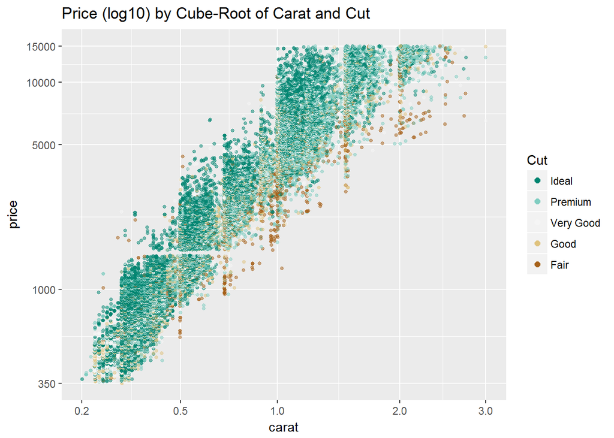

```r
ggplot(aes(x = carat, y = price, color = cut), data = diamonds) +
  geom_point(alpha = 0.5, size = 1, position = 'jitter') +
  scale_color_brewer(type = 'div',
                     guide = guide_legend(title = 'Cut', reverse = T,
                                          override.aes = list(alpha = 1, size = 2))) +
  scale_x_continuous(trans = cuberoot_trans(), limits = c(0.2, 3),
                     breaks = c(0.2, 0.5, 1, 2, 3)) +
  scale_y_continuous(trans = log10_trans(), limits = c(350, 15000),
                     breaks = c(350, 1000, 5000, 10000, 15000)) +
  ggtitle('Price (log10) by Cube-Root of Carat and Cut')
```

### Cut and Price

Response:

### Price vs. Carat and Color

Alter the code below.

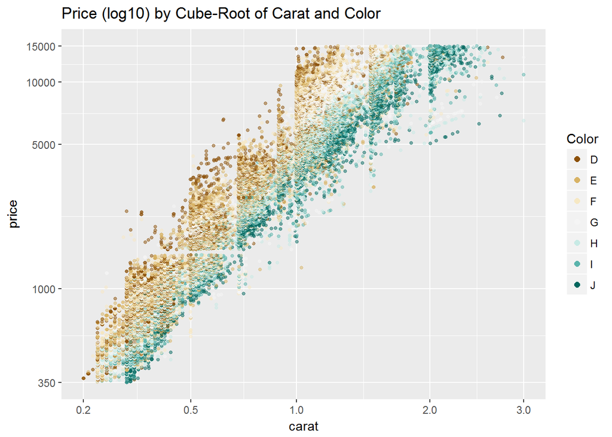

```r
ggplot(aes(x = carat, y = price, color = color), data = diamonds) +
  geom_point(alpha = 0.5, size = 1, position = 'jitter') +
  scale_color_brewer(type = 'div',
                     guide = guide_legend(title = 'Color',reverse = FALSE,
                                          override.aes = list(alpha = 1, size = 2))) +
  scale_x_continuous(trans = cuberoot_trans(), limits = c(0.2, 3),
                     breaks = c(0.2, 0.5, 1, 2, 3)) +
  scale_y_continuous(trans = log10_trans(), limits = c(350, 15000),
                     breaks = c(350, 1000, 5000, 10000, 15000)) +
  ggtitle('Price (log10) by Cube-Root of Carat and Color')
```

Here, I made four changes to the previous code. I replaced cut with color in the aesthetic wrapper. I also changed the legend title and the plot title, to use the word color. And finally, I removed the reverse parameter in the legend, so that the best color would be at the top of the list in the legend

### Color and Price

Response:

Color does seem to explain some of the variance in price. Just like we saw with the clarity variable. Blue now however, states that the difference between all color grades from D to J are basically not noticeable to the naked eye. Yet, we do see the color difference in the price tag.

### Linear Models in R

Notes:

In R we create the models using the lm(). We need to supply a formula in the form of y~x. Here, y is the outcome variable and x is the explanatory variable

**lm(log(price) ~ carat^(1/3) )**

Price is the outcome and carat is the predictor variable. We used our domain knowledge of diamonds and carat weight to take the cube root of carat weight (volume).

Response:

### Building the Linear Model

Notes: [Linear models and operators in R](http://data.princeton.edu/R/linearModels.html)

Let’s build up our linear model for price. store the first model in a variable called m1.

The “I” stands for as is. In this case, it tells R to use the expression inside the **“I” function to transform a variable before using it in the regression. This is instead of instructing R to interpret these symbols as part of the formula to construct the design matrix for the regression**.

I can also update the previous model to add the carat variable in the regression, using the syntax. The real functional relationship is surely not as simple as the cubed root of carat, so we add a simple linear function of carat in our model predicting price. And we can continue to make more complex models by adding more variables. We add cut even though we don’t expect it to have much influence on price. Next, we add color to a fourth model and clarity to a fifth. When we run the code, we can see that we’re getting some very nice R square values.

```r
m1 <- lm(I(log(price)) ~ I(carat^(1/3)), data = diamonds)
m2 <- update(m1, ~ . + carat)
m3 <- update(m2, ~ . + cut)
m4 <- update(m3, ~ . + color)
m5 <- update(m4, ~ . + clarity)
mtable(m1, m2, m3, m4, m5,sdigits = 3)
```

```
##
## Calls:
## m1: lm(formula = I(log(price)) ~ I(carat^(1/3)), data = diamonds)
## m2: lm(formula = I(log(price)) ~ I(carat^(1/3)) + carat, data = diamonds)
## m3: lm(formula = I(log(price)) ~ I(carat^(1/3)) + carat + cut, data = diamonds)
## m4: lm(formula = I(log(price)) ~ I(carat^(1/3)) + carat + cut + color,
##     data = diamonds)
## m5: lm(formula = I(log(price)) ~ I(carat^(1/3)) + carat + cut + color +
##     clarity, data = diamonds)
##
## ============================================================================================
##                        m1             m2             m3             m4            m5
## --------------------------------------------------------------------------------------------
##   (Intercept)          2.821***       1.039***       0.874***      0.932***       0.415***
##                       (0.006)        (0.019)        (0.019)       (0.017)        (0.010)
##   I(carat^(1/3))       5.558***       8.568***       8.703***      8.438***       9.144***
##                       (0.007)        (0.032)        (0.031)       (0.028)        (0.016)
##   carat                              -1.137***      -1.163***     -0.992***      -1.093***
##                                      (0.012)        (0.011)       (0.010)        (0.006)
##   cut: .L                                            0.224***      0.224***       0.120***
##                                                     (0.004)       (0.004)        (0.002)
##   cut: .Q                                           -0.062***     -0.062***      -0.031***
##                                                     (0.004)       (0.003)        (0.002)
##   cut: .C                                            0.051***      0.052***       0.014***
##                                                     (0.003)       (0.003)        (0.002)
##   cut: ^4                                            0.018***      0.018***      -0.002
##                                                     (0.003)       (0.002)        (0.001)
##   color: .L                                                       -0.373***      -0.441***
##                                                                   (0.003)        (0.002)
##   color: .Q                                                       -0.129***      -0.093***
##                                                                   (0.003)        (0.002)
##   color: .C                                                        0.001         -0.013***
##                                                                   (0.003)        (0.002)
##   color: ^4                                                        0.029***       0.012***
##                                                                   (0.003)        (0.002)
##   color: ^5                                                       -0.016***      -0.003*
##                                                                   (0.003)        (0.001)
##   color: ^6                                                       -0.023***       0.001
##                                                                   (0.002)        (0.001)
##   clarity: .L                                                                     0.907***
```

[output cut: 10 more lines]

```
##                                                                                  (0.002)
##   clarity: ^7                                                                     0.032***
##                                                                                  (0.001)
## --------------------------------------------------------------------------------------------
##   R-squared            0.924          0.935          0.939         0.951          0.984
##   adj. R-squared       0.924          0.935          0.939         0.951          0.984
##   sigma                0.280          0.259          0.250         0.224          0.129
##   F               652012.063     387489.366     138654.523     87959.467     173791.084
##   p                    0.000          0.000          0.000         0.000          0.000
##   Log-likelihood   -7962.499      -3631.319      -1837.416      4235.240      34091.272
##   Deviance          4242.831       3613.360       3380.837      2699.212        892.214
##   AIC              15930.999       7270.637       3690.832     -8442.481     -68140.544
##   BIC              15957.685       7306.220       3761.997     -8317.942     -67953.736
##   N                53940          53940          53940         53940          53940
## ============================================================================================
```

```r
# sdigits = 3 ensures we get 3 significant digits
```

```r
m1
```

```
##
## Call:
## lm(formula = I(log(price)) ~ I(carat^(1/3)), data = diamonds)
##
## Coefficients:
##    (Intercept)  I(carat^(1/3))
##          2.821           5.558
```

#### the intercept

##### what’s the values inside the parentheses under each coefficient?

The values found in the parentheses below each coefficient indicate the **standard error for the estimate of the coefficient**, while the **asterisks next to the coefficent values state whether or not the coefficients are statistically significant**.

The hypothesis being tested here is whether or not the coefficient is significantly different from 0. One asterisk appears at a significance level of 0.05, with up to three appearing as the statistical significance approaches 0. As with traditional hypothesis tests, you can get coefficients that are very close to 0 but are treated as statistically significant, perhaps due to a large volume of data points, so don’t just rely on the p-values and significance indicators when interpreting your results - make sure you look at the coefficient values as well.

#### there are five levels of cut, but the linear model only generate four coefficients why?

Stated succinctly, we only need n - 1 variables to describe the trends found in a categorical or ordinal feature with n levels, since the intercept provides a baseline upon which the levels’ effects act as modifiers.

In the model cut coefficient names are cut.L, cut.Q, cut.C, and cut^4. L means linear, Q means quadratic, and C means cubic.

**In a linear model, feature values are multiplied by coefficients to depict their contribution to the predicted outcome value**, but what exactly that ‘feature value’ is depends on the type of feature that is being fit. We make a distinction between **four different types of variables when it comes to classification: Categorical, Ordinal, Interval, and Ratio**.

**Interval and Ratio** variables are treated straightforwardly: the raw value of the feature is inserted into our linear model equation directly, and multiplied by the value of the corresponding coefficient.

**Categorical features** are a little bit more complicated; instead of a single coefficient associated with a categorical feature, we use a set of dummy variables to encode the individual levels of the category. With a categorical feature of n levels, n - 1 dummy variables are enough to describe the change between category levels, assuming that there is a separate “intercept” coefficient. Each dummy variable corresponds with a single level of the categorical variable, and the feature value associated with the dummy is 1 if a data point is in that level, or 0 if the data point is not. In this way, each data point flags a 1 for at most one dummy variable, and a 0 for all others. This flagged dummy coefficient shows the contribution of the category to the outcome prediction as a difference from the intercept baseline. (In the case where all dummies are 0, the data point is part of the category level not encoded by the dummy and its value is captured by the intercept.)

**Ordered variables** are the most complicated ones to handle, and bear qualities that are in between categorical variables and interval/ratio variables. **Much like categorical variables, if we have n levels in our ordered feature, we will have n - 1 coefficients associated with the ordered feature**. But **unlike categorical variables, the feature values for data points on the ordered variable will not simply take values of 0 and 1. Instead, the values are based on polynomial contrasts that try to preserve the ordered nature of the levels in the variable while also recognizing that, unlike an interval or ratio scale, the differences between consecutive levels of an ordered variable may not be equal. Each of the contrast coefficients associated with the ordered variable is also associated with a different order of polynomial**.

Being an ordinal variable, however, it may not be the case that there are equal gaps between levels - the difference between Fair and Good may not be the same as the difference between Good and Very Good.

If we do not want to assume equal gaps between levels, then we can look at higher-order contrasts.

These properties carry through all of the contrasts. The contrasts’ orthogonality is important to maintain independence between terms; we want to avoid interaction effects here.

You can **print out a matrix of these contrasts using the contr.poly(n) function, where n is the number of levels**.

One final thing to think about: __ why do we want to do this?__

We could just as easily treat the ordered factor as categorical, and we can more easily interpret the coefficients associated with each of the feature levels due to the binary (0-1) nature of dummy variable values. However, **the coefficients of the polynomial contrasts allows us to see the complexity in the relationship between the levels of the ordered variable**. Is there a linear trend in levels? How impactful are the higher-order polynomials? How much would we lose by simplifying the system and treating the ordered variable as an continuous interval variable (only having the linear contrast)?

To provide a concrete example, for the diamond dataset’s cut variable, we have five ordered levels: [Fair, Good, Very Good, Premium, Ideal]. Consequently, the complete set of polynomial contrasts provides four coefficients: [L, Q, C, ^4], representing the linear, quadratic, cubic, and quartic trends. ‘contr.poly(5)’ gives us the contrast matrix.

```r
contr.poly(5)
```

```
##              .L         .Q            .C         ^4
## [1,] -0.6324555  0.5345225 -3.162278e-01  0.1195229
## [2,] -0.3162278 -0.2672612  6.324555e-01 -0.4780914
## [3,]  0.0000000 -0.5345225 -4.095972e-16  0.7171372
## [4,]  0.3162278 -0.2672612 -6.324555e-01 -0.4780914
## [5,]  0.6324555  0.5345225  3.162278e-01  0.1195229
```

[-0.632, -0.316, 0.000, 0.316, 0.632] is the 1st column of above matrix

If we have a diamond of cut quality “Premium”, this is the fourth level of the cut feature. Looking on the fourth row of the matrix, we can see what values the point will take in the linear model. 0.316, in the first column, will be multiplied by the “cut:L” coefficient. -0.267, in the second column, will be multiplied by the “cut:Q” coefficient. Summing over the product of values and coefficients (dot product), we see the overall contribution of the data point’s cut to the prediction of price.

As alluded to above, this is not a direct way of showing the contribution - if you want a more straightforward way of doing that you may want to treat the data as a categorical variable instead of ordered, then look at the generated coefficients on the dummy variables. But this way of looking at things allows you to see how closely the levels of an ordered factor resemble that of a standard numeric measure (interval or ratio scale) or how they differ. You can do some internet searches for more information about contrasts, which are used in regression and hypothesis testing such as in ANOVA.

We’re accounting for almost all of the variance in price using the four “C”s. If we want to know whether the price for, a diamond is reasonable, we might now use this model.

Notice how adding cut to our model does not help explain much of the variance in the price of diamonds. This fits with out exploration earlier.

### Model Problems

And finally, after looking at the data on price scope, I realize that diamond prices grew unevenly across different carat sizes since 2008, meaning that the model I initially estimated couldn’t simply be adjusted by inflation.

### A Bigger, Better Data Set

Notes:

```r
#install.packages('bitops')
#install.packages('RCurl')
library('bitops')
library('RCurl')
load("BigDiamonds.rda")
```

The code used to obtain the data is available here: https://github.com/solomonm/diamonds-data

## Building a Model Using the Big Diamonds Data Set

Notes:

We’ll only use GIA certified diamonds in this log. I look only at diamonds under $10,000 because these are the type of diamonds sold at most retailers, and hence, the kind we care most about. By trimming the most expensive diamonds from the data set, our model will also be less likely to be thrown off by outliers, and the higher variants at the high-end of price and carat.

```r
diamondsbig$logprice = log(diamondsbig$price)
mb1 <- lm(logprice ~ I(carat^(1/3)), data=diamondsbig[diamondsbig$price<10000 & diamondsbig$cert=="GIA", ])
mb2 <- update(mb1, ~ . + carat)
mb2 <- update(mb1, ~ . + carat)
mb3 <- update(mb2, ~ . + cut)
mb4 <- update(mb3, ~ . + color)
mb5 <- update(mb4, ~ . + clarity)

#(Tables your models and pulls out the statistics)
modelsbig <- mtable(mb1, mb2, mb3, mb4, mb5)
modelsbig
```

```
##
## Calls:
## mb1: lm(formula = logprice ~ I(carat^(1/3)), data = diamondsbig[diamondsbig$price <
##     10000 & diamondsbig$cert == "GIA", ])
## mb2: lm(formula = logprice ~ I(carat^(1/3)) + carat, data = diamondsbig[diamondsbig$price <
##     10000 & diamondsbig$cert == "GIA", ])
## mb3: lm(formula = logprice ~ I(carat^(1/3)) + carat + cut, data = diamondsbig[diamondsbig$price <
##     10000 & diamondsbig$cert == "GIA", ])
## mb4: lm(formula = logprice ~ I(carat^(1/3)) + carat + cut + color,
##     data = diamondsbig[diamondsbig$price < 10000 & diamondsbig$cert ==
##         "GIA", ])
## mb5: lm(formula = logprice ~ I(carat^(1/3)) + carat + cut + color +
##     clarity, data = diamondsbig[diamondsbig$price < 10000 & diamondsbig$cert ==
##     "GIA", ])
##
## ================================================================================================
##                        mb1             mb2             mb3            mb4            mb5
## ------------------------------------------------------------------------------------------------
##   (Intercept)           2.671***        1.333***       0.949***       0.529***       -0.464***
##                        (0.003)         (0.012)        (0.012)        (0.010)         (0.009)
##   I(carat^(1/3))        5.839***        8.243***       8.633***       8.110***        8.320***
##                        (0.004)         (0.022)        (0.021)        (0.017)         (0.012)
##   carat                                -1.061***      -1.223***      -0.782***       -0.763***
##                                        (0.009)        (0.009)        (0.007)         (0.005)
##   cut: V.Good                                          0.120***       0.090***        0.071***
##                                                       (0.002)        (0.001)         (0.001)
##   cut: Ideal                                           0.211***       0.181***        0.131***
##                                                       (0.002)        (0.001)         (0.001)
##   color: K/L                                                          0.123***        0.117***
##                                                                      (0.004)         (0.003)
##   color: J/L                                                          0.312***        0.318***
##                                                                      (0.003)         (0.002)
##   color: I/L                                                          0.451***        0.469***
##                                                                      (0.003)         (0.002)
##   color: H/L                                                          0.569***        0.602***
##                                                                      (0.003)         (0.002)
##   color: G/L                                                          0.633***        0.665***
##                                                                      (0.003)         (0.002)
##   color: F/L                                                          0.687***        0.723***
##                                                                      (0.003)         (0.002)
```

[output cut: 17 more lines]

```
##                                                                                      (0.006)
##   clarity: IF                                                                         1.052***
##                                                                                      (0.006)
## ------------------------------------------------------------------------------------------------
##   R-squared             0.888           0.892          0.899          0.937           0.969
##   adj. R-squared        0.888           0.892          0.899          0.937           0.969
##   sigma                 0.289           0.284          0.275          0.216           0.154
##   F               2700903.714     1406538.330     754405.425     423311.488      521161.443
##   p                     0.000           0.000          0.000          0.000           0.000
##   Log-likelihood   -60137.791      -53996.269     -43339.818      37830.414      154124.270
##   Deviance          28298.689       27291.534      25628.285      15874.910        7992.720
##   AIC              120281.582      108000.539      86691.636     -75632.827     -308204.540
##   BIC              120313.783      108043.473      86756.037     -75482.557     -307968.400
##   N                338946          338946         338946         338946          338946
## ================================================================================================
```

What we will do first is make a variable called logged price, the log of diamond price.

And then we will build our model similarly to the way that we did for the small diamond status set. Notice that we’re setting price by diamonds whose price is less than $10,000 and whose certificate is G.I.A.. Thankfully our models look quite a bit like they did for the smaller diamond status set. Although our R squared values are just a touch weaker.

## Predictions

After all this work, let’s use our model to make a prediction. **We need to exponentiate the result of our model. Since we took the log of price.**

Example Diamond from BlueNile: Round 1.00 Very Good I VS1 $5,601

```r
#Be sure you have loaded the library memisc and have m5 saved as an object in your workspace.
thisDiamond = data.frame(carat = 1.00, cut = "V.Good",
                         color = "I", clarity="VS1")
modelEstimate = predict(mb5, newdata = thisDiamond,
                        interval="prediction", level = .95)
```

```r
exp(modelEstimate)
```

```
##        fit     lwr      upr
## 1 5040.436 3730.34 6810.638
```

Evaluate how well the model predicts the BlueNile diamond’s price. Think about the fitted point estimate as well as the 95% CI.

**Ans:** The results yield an expected value for price given the characteristics of our diamond, and the upper and lower bounds of a 95% confidence level.

Note, because this is a linear model, predict is just multiplying each model coefficient by each value in our data. It turns out that this diamond is a touch pricier than the expected value under the full model, though it is by no means outside of the 95% confidence interval.

```
dat = data.frame(m4$model, m4$residuals)

with(dat, sd(m4.residuals))

with(subset(dat, carat > .9 & carat < 1.1), sd(m4.residuals))

dat$resid <- as.numeric(dat$m4.residuals)

ggplot(aes(y = resid, x = round(carat, 2)), data = dat) +
  geom_line(stat = "summary", fun.y = sd)
```

```r
dat = data.frame(mb4$model, mb4$residuals)
with(dat, sd(mb4.residuals))
```

```
## [1] 0.2164168
```

```r
with(subset(dat, carat > .9 & carat < 1.1), sd(mb4.residuals))
```

```
## [1] 0.2178147
```

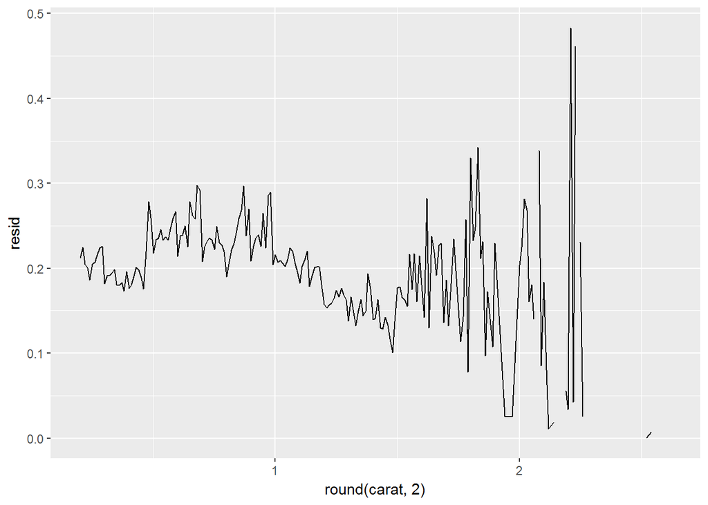

```r
dat$resid <- as.numeric(dat$mb4.residuals)

ggplot(aes(y = resid, x = round(carat, 2)), data = dat) +
  geom_line(stat = "summary", fun.y = sd)
```

How could we do better? If we care most about diamonds with carat weights between 0.50 and 1.50, we might restrict the data we use to fit our model to diamonds that are that size - we have enough data.